# The effect of bacteria on the *A. thaliana* Pi starvation response

Sur Herrera Paredes

2022-03-31

This document was created for the workshop **Data Management for Publishing: Accessibility and Reproducibility**, to be taught on April 23rd, 2022. All resources for the Rmarkdown session of the workshop, plus some additional ones, can be found in the GitHub repository surh/Rmarkdown_workshop.

The data and code in this document reproduce some of the analysis from Herrera Paredes et al. (2018). The full data and code from that publication can be found in the GitHub repository surh/wheelP.

# Setup

The first step is to load the packages and data that we need for analysis. We will use the [tidyverse](https://www.tidyverse.org/) collection of packages.

We do that by creating our first R code chunk, which should start with the line `` ```{r chunk_name} ``, followed by any R code, and ends with a line with a triple backtick (`` ``` ``). When we press `Ctrl+Shift+k` in RStudio, any R code within the code chunk will be run and both the code and its output will be rendered nicely into an output file.

```r
library(tidyverse)
```

Now, we read the data which is in the `data` directory of the [GitHub repository](https://github.com/surh/Rmarkdown_workshop) of the workshop. Since the input file is a tab-delimited file, we use the `read_tsv` function from the `readr` package (which was automatically loaded when we loaded the `tidyverse` package).

After reading the file, we simply print the first few rows to inspect it.

```r
Dat <- read_tsv(params$data_file,
                col_types = cols(Pi_content = col_number(),
                                 Elongation = col_number(),
                                 Experiment = col_character(),
                                 EndP = col_character(),
                                 Bacteria = col_character(),
                                 Plate = col_character()))
Dat
```

```
## # A tibble: 60 × 6
##    Pi_content Elongation Experiment EndP         Bacteria Plate
##         <dbl>      <dbl> <chr>      <chr>        <chr>    <chr>
##  1      10.9        6.43 A          30 uM,0%Suc  axenic   1
##  2      12.0        5.97 A          30 uM,0%Suc  axenic   2
##  3      11.3        5.38 A          30 uM,0%Suc  axenic   3
##  4       3.05       4.88 A          30 uM,0%Suc  P1P2     4
##  5       2.46       4.66 A          30 uM,0%Suc  P1P2     5
##  6       4.85       4.46 A          30 uM,0%Suc  P1P2     6
##  7       7.61       4.73 A          30 uM,0%Suc  I1I2     13
##  8       7.09       4.46 A          30 uM,0%Suc  I1I2     14
##  9       5.03       4.51 A          30 uM,0%Suc  I1I2     15
## 10      11.1        5.65 A          100 uM,0%Suc axenic   19
## # … with 50 more rows
```

This dataset contains 60 observations. The observations correspond to a subset of the observations published by Herrera Paredes et al. (2018). Specifically, the dataset indicates the shoot phosphate (Pi) content ($\frac{Pi\ mmol }{FW\ mg}$), and main root elongation (cm) measurements of *Arabidopsis thaliana* plants that were germinated in the absence of Pi, and then received concurrent treatments of one of two levels of Pi ($30 \mu M$, $100 \mu M$), and one of three bacterial cocktails (P1P2, I1I2, N2N3) or no bacteria (axenic).

# Sanity checks

When *A .thaliana* plants are starved for Pi, they suppress the elongation of their main root, because in the soils where they live, Pi is located in the topmost layers.

We confirm that we observe this general trend by plotting the `Elongation` & `Pi_content` measurements in a scatter plot. We can use the `ggplot` function from the `ggplot2` package (which also was loaded as part of the `tidyverse` package).

Because there are two Pi conditions, we plot each the observations from each condition in a different color (`col = EndP`), and we add a linear regression line (i.e. a *trendline*) on each group of observations with the `geom_smooth` function. Finally, we set the `theme_classic()` theme which makes for less busy looking plots.[^1]

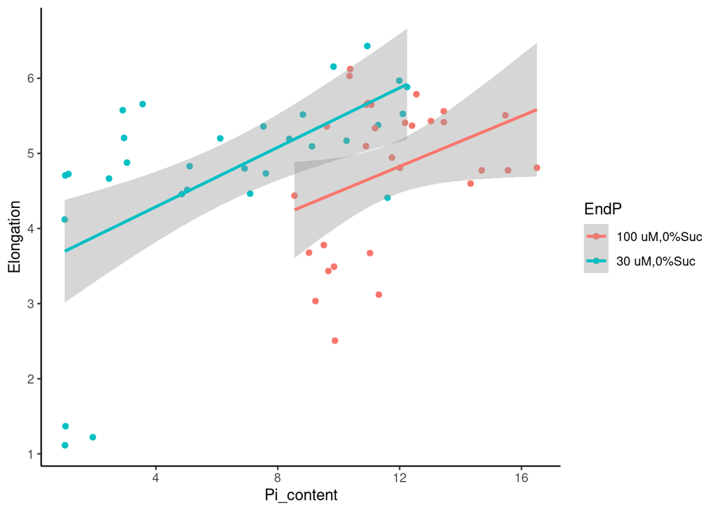

Scatter plot of main root elongation (Elongation) and shoot Pi content (Pi_content).

```r
Dat %>%
  ggplot(aes(x = Pi_content, y = Elongation, col = EndP)) +
  geom_point() +
  geom_smooth(method = "lm", formula = y ~ x) +
  theme_classic()
```

We observe that there are three apparent outliars in the bottom left corner of the plot. It is important to investigate those further, so we sort the dataset by Elongation to investigate further. We can do that with the `arrange` function of the `dplyr` package, which is another one of those packages automagically loaded when loading `tidyverse`. By default, `arrange` sorts things in increasing order.

```r
Dat %>%
  arrange(Elongation)
```

```
## # A tibble: 60 × 6
##    Pi_content Elongation Experiment EndP         Bacteria Plate
##         <dbl>      <dbl> <chr>      <chr>        <chr>    <chr>
##  1       1.01       1.11 C          30 uM,0%Suc  N2N3     11
##  2       1.93       1.22 C          30 uM,0%Suc  N2N3     10
##  3       1.03       1.37 C          30 uM,0%Suc  N2N3     12
##  4       9.88       2.51 D          100 uM,0%Suc N2N3     Y
##  5       9.24       3.03 A          100 uM,0%Suc P1P2     24
##  6      11.3        3.12 A          100 uM,0%Suc P1P2     22
##  7       9.66       3.43 A          100 uM,0%Suc P1P2     23
##  8       9.85       3.49 D          100 uM,0%Suc N2N3     Z
##  9      11.0        3.67 D          100 uM,0%Suc N2N3     A1
## 10       9.03       3.68 C          100 uM,0%Suc N2N3     25
## # … with 50 more rows
```

When we examine the observation with the three smalles elongation measurements, we note that all come from the same experiment and treatment. It seems likely that something went wrong with those observations, so we should remove them from further analysis.

There is more than one way to do it, but one convenient function is `filter` which is part of the `dplyr` package, and allows us to specify a condition that must be met for rows in our dataset to be kept, everything else is removed.

```r
Dat <- Dat %>%
  filter(Elongation > 2)
```

After removing outliars, w have 57 observations (i.e. rows) in the dataset.

It is always a good idea to check that the overall trends didn’t change with the removal of the outliars (and after any type of subsetting). So we can make the same plot again with the modified dataset. This time, we also save the plot to the `p1` variable.

Note that if we just copy the chunk from the first scatter plot (with the outliars), we would get an error because the chunk names would be the same. So we need to change the name to something unique before rendering the RMarkdown file.

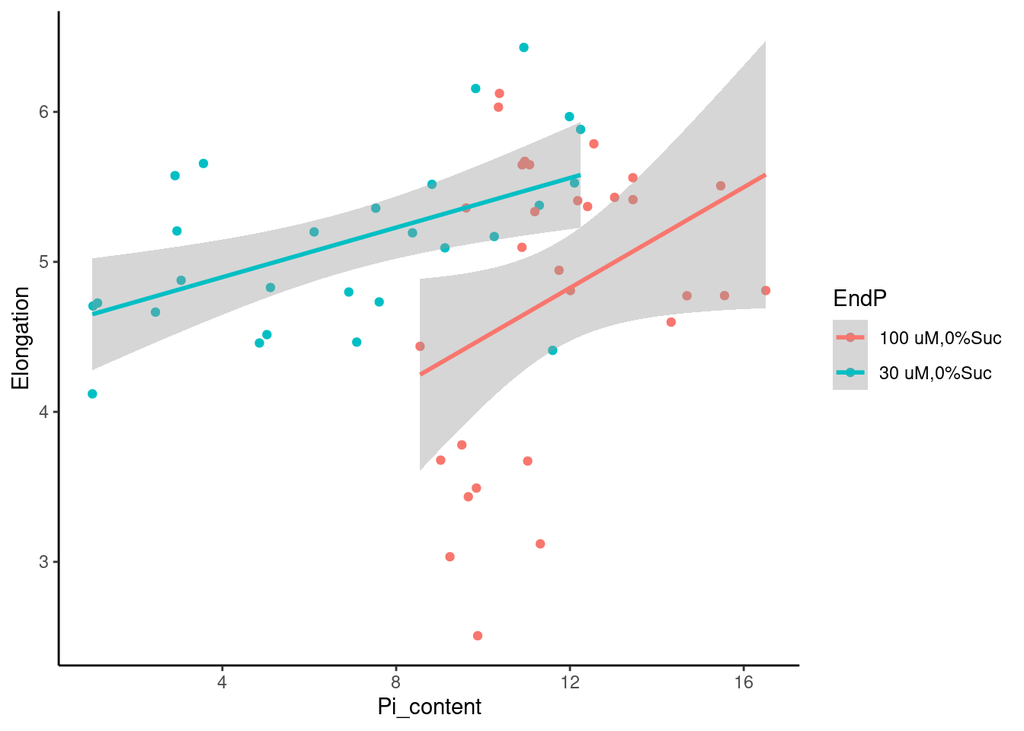

Scatter plot of main root elongation (Elongation) and shoot Pi content (Pi_content) with outliars removed.

```r
p1 <- Dat %>%
  ggplot(aes(x = Pi_content, y = Elongation, col = EndP)) +
  geom_point() +
  geom_smooth(method = "lm", formula = y ~ x) +
  theme_classic()
p1
```

Overall, the trends remain the same after we removed the outliars, which was expected.

## Is the association statiscally supported?

The plots above show that the relationship between plant shoot Pi content and main root elongation, follow the expected trend, but how strong is the relationship? and is it statistically supported?

We can quantify the correlation with the `cor` base R function, and obtain a *p*-value with the `cor.test()` function which outputs a list with an element named `p.value`.

With these tools, we calculate that the overall correlation between the Pi content and root elongation phenotypes is **0.148973** which has a *p*-value of 0.2687312 which is not significant.

However, we want to calculate the correlation independently for each condition.

- The correlation between the Pi content and root elongation in the $30 \mu M$ Pi condition is **0.5328405** which has a *p*-value of 0.0042159.
- The correlation between the Pi content and root elongation in the $100 \mu M$ Pi condition is **0.3564981** which has a *p*-value of 0.053147.

Thus the effect correlation of between Pi starvation & main root elongation is stronger when the Pi starvation is more severe.

### Controling for covariates

While we compared the association between the plant phenotypes in two conditions, the dataset contains another variable, which is the bacterial cocktail (`Bacteria`) added to the plants, so a full analysis must consider the effect of the bacterial treatment, as well as the experimental variation between replicates.

Without going into details, a first approximation to this problem[^2] can be achieved with the base R `lm` function, which allows us to fit a linear model that attempts to explain the variation in main root elongation, as a function of all the other variables (biological & technical).

The statistical model is defined by a `formula` object, which we save to a variable `f1`. After fitting the model we display the results with the R base function `summary`.

```r
f1 <- Elongation ~ Pi_content + Bacteria + EndP + Experiment
m1 <- lm(f1, data = Dat)
summary(m1)
```

```
##
## Call:
## lm(formula = f1, data = Dat)
##
## Residuals:
##      Min       1Q   Median       3Q      Max
## -1.19435 -0.16838 -0.01681  0.28101  1.03194
##
## Coefficients:
##                 Estimate Std. Error t value Pr(>|t|)
## (Intercept)      6.16213    0.56181  10.968 1.13e-14 ***
## Pi_content      -0.06016    0.03628  -1.658  0.10381
## BacteriaI1I2    -0.80842    0.25264  -3.200  0.00244 **
## BacteriaN2N3    -1.53004    0.31326  -4.884 1.19e-05 ***
## BacteriaP1P2    -1.37803    0.27154  -5.075 6.24e-06 ***
## EndP30 uM,0%Suc -0.04240    0.24217  -0.175  0.86176
## ExperimentB      0.55406    0.18383   3.014  0.00411 **
## ExperimentC     -0.14030    0.27756  -0.505  0.61554
## ExperimentD     -0.39222    0.27293  -1.437  0.15718
## ---
## Signif. codes:  0 '***' 0.001 '**' 0.01 '*' 0.05 '.' 0.1 ' ' 1
##
## Residual standard error: 0.5507 on 48 degrees of freedom
## Multiple R-squared:  0.6241, Adjusted R-squared:  0.5615
## F-statistic: 9.962 on 8 and 48 DF,  p-value: 4.843e-08
```

Here we can see that there are statistically signigicant (i.e. *p*-value < 0.05) effects for the different bacterial treatments and for some experiments. However there no effect of the Pi concentration in the media at the second part of the experiment (EndP), and it seems like the shoot Pi content is also not statistically significant.[^3]

Given the small sample size, models with a lot of parameters tend to suffer of something called *over-fitting* which basically means that the model confuses noise for signal. So in general, it is a good practice to check if a simpler model can do an equally good job at explaining your data.

We can thus check whether a model without the `EndP` variable, which had the largest *p*-value in the previous model. To do that, we change the formula by removing that variable, fit the new (`m2`) model and then we perform a Likelihood Ratio Test (LRT) with the base R `anova` function. You can do all this much more simply with the `lmtest` package, but we are restricting ourselves here to base functions.

```r
f2 <- Elongation ~ Pi_content + Bacteria + Experiment
m2 <- lm(f2, data = Dat)
anova(m1, m2, test = "LRT")
```

```
## Analysis of Variance Table
##
## Model 1: Elongation ~ Pi_content + Bacteria + EndP + Experiment
## Model 2: Elongation ~ Pi_content + Bacteria + Experiment
##   Res.Df    RSS Df  Sum of Sq Pr(>Chi)
## 1     48 14.559
## 2     49 14.569 -1 -0.0092972    0.861
```

The *p*-value in the output above is clearly above 0.05 and thus it indicates clearly that there is no significant difference in explanatory power between the models. Thus we select the simpler one (`m2`) and we display the results with the base R `summary` function.

```r
summary(m2)
```

```
##
## Call:
## lm(formula = f2, data = Dat)
##
## Residuals:
##      Min       1Q   Median       3Q      Max
## -1.18110 -0.17662 -0.01317  0.29823  1.02536
##
## Coefficients:
##              Estimate Std. Error t value Pr(>|t|)
## (Intercept)   6.08140    0.31775  19.139  < 2e-16 ***
## Pi_content   -0.05514    0.02199  -2.507  0.01553 *
## BacteriaI1I2 -0.79247    0.23330  -3.397  0.00136 **
## BacteriaN2N3 -1.50038    0.26089  -5.751 5.65e-07 ***
## BacteriaP1P2 -1.35696    0.24097  -5.631 8.62e-07 ***
## ExperimentB   0.55274    0.18185   3.040  0.00379 **
## ExperimentC  -0.13155    0.27031  -0.487  0.62867
## ExperimentD  -0.39225    0.27022  -1.452  0.15298
## ---
## Signif. codes:  0 '***' 0.001 '**' 0.01 '*' 0.05 '.' 0.1 ' ' 1
##
## Residual standard error: 0.5453 on 49 degrees of freedom
## Multiple R-squared:  0.6239, Adjusted R-squared:  0.5701
## F-statistic: 11.61 on 7 and 49 DF,  p-value: 1.366e-08
```

The output of summary contains a lot of useful information, but sometimes we are interested just in the table of coeffients and *p*-values, which is what is typically reported in scientific publications. We could simply `summary(m2)$coefficients` which access the `coefficients` table produced by the `summary` function, but that still displays the results as R output which is not necessarily the most easy to read or export.

We could also save the resutls to a file with functions like `write_tsv` or `write_csv` of the readr package (or `write.table` from base R), but then we lose the advantage of displaying code and output together.

Instead, we can convert any matrix or data.frame into a Markdown formatted table with the `kable` function of the knitr package. Since we haven’t loaded this package we can access the function with the `package::function` syntax which tells R in which package (or more technically namespace) a function is. For the `kable` function to work we also need to set the `results = "asis"` option in the code chunk options. Finally we can add a caption with the `caption` option of the `kable` function.

|  | Estimate | Std. Error | t value | Pr(>\|t\|) |
| --- | --- | --- | --- | --- |
| (Intercept) | 6.0813955 | 0.3177538 | 19.1387010 | 0.0000000 |
| Pi_content | -0.0551412 | 0.0219915 | -2.5073860 | 0.0155267 |
| BacteriaI1I2 | -0.7924710 | 0.2333011 | -3.3967741 | 0.0013611 |
| BacteriaN2N3 | -1.5003824 | 0.2608860 | -5.7511041 | 0.0000006 |
| BacteriaP1P2 | -1.3569574 | 0.2409728 | -5.6311631 | 0.0000009 |
| ExperimentB | 0.5527432 | 0.1818468 | 3.0396086 | 0.0037947 |
| ExperimentC | -0.1315495 | 0.2703103 | -0.4866612 | 0.6286682 |
| ExperimentD | -0.3922542 | 0.2702165 | -1.4516293 | 0.1529776 |

# Summary

As conclusions from our analysis we have that:

1. There is an effect of shot Pi content in main root elongation. This effect seems to be stronger in more Pi limiting conditions but that difference is not statistically significant.
2. The specific bacterial cocktail used has the strongest effect on main root elongation.
3. In general, the presence of bacteria decreases main root elongation, which is consistent with the published analysis by Herrera Paredes et al. (2018).

We can illustrate the first conclusion with the earlier scatter plot between Pi content & root elongation (saved to `p1`), and create a boxplot for conclusion 2. For conclusion 3, it would be nice to include an external figure from the original publication.

We can add a figure from an image file anywhere outside outside of a code chunk with the syntax `![catpiton](path/to/image/file)`, but we lose some of the ability to control its appearance. Instead, we can display the image from a code chunk with the `include_graphics` function from the knitr package.

Finally, we can display multiple images side by side if we add the code chunk option `fig.show="hold"` and we play with the code chunk option `out.width`.

With this tools we can now make the final plot and display the three images that illustrate our conclusions.

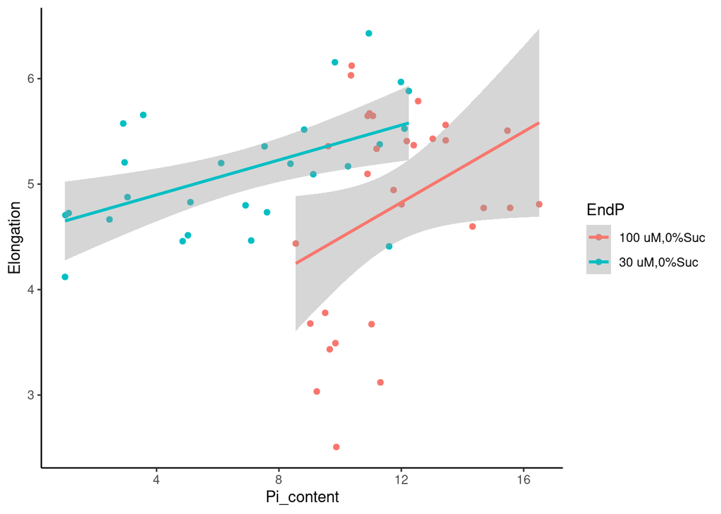

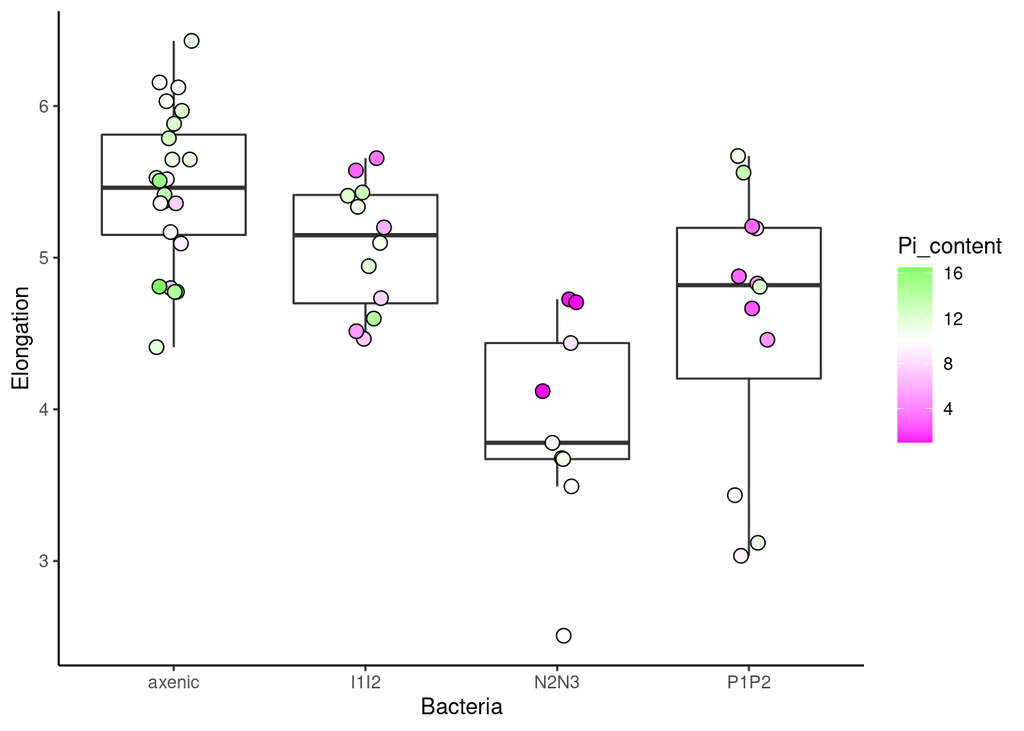

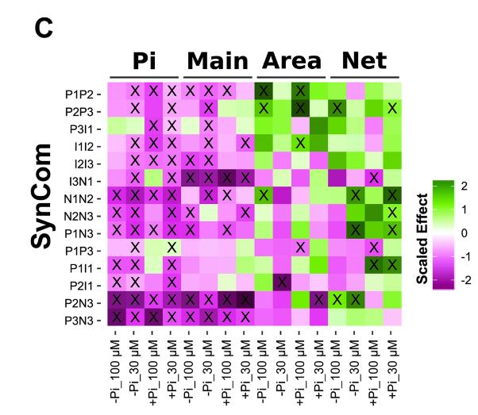

**Left**: Correlation between shoot Pi content and main root elongation in different environmental Pi levels. **Center**: Distribution of main root elongation measurements stratified by bacterial treatment. Color indicates corresponding shoot Pi content. **Right**: figure 3C from Herrera Paredes et al. (2018) showing confirming that most bacterial cocktails decrease main root elongation.

```r
p1
Dat %>%
  ggplot(aes(x = Bacteria, y = Elongation)) +
  geom_boxplot(outlier.color = NA) +
  geom_point(aes(fill = Pi_content),
             position = position_jitter(width = 0.1),
             shape = 21, size = 3) +
  scale_fill_gradient2(low = "magenta",
                       mid = "white", high = "green",
                       midpoint = 10) +
  theme_classic()
knitr::include_graphics("figs/Fig3C.jpeg")
```

# References

Herrera Paredes, Sur, Tianxiang Gao, Theresa F. Law, Omri M. Finkel, Tatiana Mucyn, Paulo José Pereira Lima Teixeira, Isaí Salas González, et al. 2018. “Design of Synthetic Bacterial Communities for Predictable Plant Phenotypes.” Edited by Eric Kemen. *PLoS Biology* 16 (2): e2003962. https://doi.org/10.1371/journal.pbio.2003962.

[^1]: The `%>%` symbol in the code below is a pipe (or more formally a FIFO operator). It is provided by the `maggrittr` package and loaded with the `tidyverse`. If you are familiar with UNIX/Linux systems, it works very similar to the shell `|` operator. Its operation is very simple, it just takes the output of its expression on the left, and it uses that output as the first parameter of the expression on its right.
[^2]: A more complete and appropriate treatment would consider the full dataset published by Herrera Paredes et al. (2018).
[^3]: Part of the lack of significance has to do with the size of the dataset and the aggregation level of the data in this example. In the original publication, there are many more observations and the measurements are less aggregated.